# Aceite de Oliva

Antonio Maudes

9 de abril de 2017

# Precios del Aceite de Oliva en España

El Ministerio de Agricultura de España indica en su [página web de precios medios](http://www.mapama.gob.es/es/estadistica/temas/estadisticas-agrarias/economia/precios-medios-nacionales/pmn_tabla.asp):

**Concepto**

- Los Precios Medios son indicadores semanales de precios medios nacionales de los productos agrarios que tienen más relevancia a nivel nacional.

**Metodología**

- Son precios medios ponderados obtenidos a partir de las cotizaciones registradas en los mercados de mayor representatividad a nivel nacional, a los que se les asignan coeficientes de ponderación fijos establecidos en función de la importancia de cada mercado en la comercialización de cada producto.

**[Precios Medios Nacionales (Metodología)](http://www.mapama.gob.es/estadistica/pags/precios-medios-nacionales/Metodologia.pdf)**

**Utilidad** Seguimiento exhaustivo de la coyuntura del mercado de cada uno de los productos especificados, a lo largo de su campaña de comercialización. Permite, mediante gráficos, su comparación con dos campañas anteriores.

Para cada producto las unidades son las establecidas por la Dirección General de Agricultura de la U.E.

# Cargar Librerías

```r
library(ggplot2)
library(dplyr)
library(lubridate)
```

# Cargar los datos

```r
library(readr)
a <- read_csv("Aceite.csv") #Precios Medios: Historico - ACEITES
a$AÑO<-factor(a$AÑO)
a$SEMANA<-factor(a$SEMANA)
str(a)
```

```
## Classes 'tbl_df', 'tbl' and 'data.frame':    126 obs. of  6 variables:
##  $ X1    : int  1 2 3 4 5 6 7 8 9 10 ...
##  $ SEMANA: Factor w/ 52 levels "1","2","3","4",..: 44 45 46 47 48 49 50 51 52 1 ...
##  $ FECHA : chr  "2013/44" "2013/45" "2013/46" "2013/47" ...
##  $ AÑO   : Factor w/ 4 levels "2013","2014",..: 1 1 1 1 1 1 1 1 1 2 ...
##  $ PRECIO: num  339 254 263 267 270 ...
##  $ Pb    : num  316 244 252 254 252 ...
##  - attr(*, "spec")=List of 2
##   ..$ cols   :List of 6
##   .. ..$ X1    : list()
##   .. .. ..- attr(*, "class")= chr  "collector_integer" "collector"
##   .. ..$ SEMANA: list()
##   .. .. ..- attr(*, "class")= chr  "collector_integer" "collector"
##   .. ..$ FECHA : list()
##   .. .. ..- attr(*, "class")= chr  "collector_character" "collector"
##   .. ..$ AÑO   : list()
##   .. .. ..- attr(*, "class")= chr  "collector_integer" "collector"
##   .. ..$ PRECIO: list()
##   .. .. ..- attr(*, "class")= chr  "collector_double" "collector"
##   .. ..$ Pb    : list()
##   .. .. ..- attr(*, "class")= chr  "collector_double" "collector"
##   ..$ default: list()
##   .. ..- attr(*, "class")= chr  "collector_guess" "collector"
##   ..- attr(*, "class")= chr "col_spec"
```

- **Precios Medios: Historico - ACEITE DE OLIVA VIRGEN DE 0.8º A 2º**

```r
a$PRECIO
```

```
##   [1] 339.05 253.64 262.73 266.66 269.60 269.75 276.14 272.20 272.23 280.58
##  [11] 287.19 292.73 289.53 294.60 295.84 299.69 296.14 295.65 295.97 298.33
##  [21] 298.39 299.23 300.06 295.98 298.14 308.01 312.86 310.53 314.79 315.20
##  [31] 315.73 321.22 321.53 327.57 324.33 321.39 345.93 355.76 367.19 374.75
##  [41] 401.14 404.25 403.69 401.83 395.21 390.33 372.74 343.83 343.89 342.01
##  [51] 343.88 340.95 339.05 315.56 299.17 292.28 286.20 286.72 290.89 290.91
##  [61] 310.92 315.74 314.66 316.52 321.21 323.15 320.77 303.20 305.05 304.83
##  [71] 303.50 304.35 301.48 301.81 300.31 299.95 299.07 299.09 289.28 282.72
##  [81] 283.01 281.65 283.51 289.65 288.59 292.72 294.75 294.87 303.93 304.82
##  [91] 305.24 305.26 305.26 305.21 306.06 311.05 312.71 312.32 311.95 311.39
## [101] 311.55 310.80 308.40 307.07 308.73 309.26 314.07 326.20 327.09 328.62
## [111] 330.75 330.83 330.41 332.55 341.95 345.95 351.78 358.15 355.66 370.65
## [121] 371.90 373.01 370.21 373.18 371.51 371.45
```

- **Precios Medios: Historico - ACEITE DE OLIVA LAMPANTE DE MÁS DE 2º (euros / 100 kg)**

```r
a$Pb
```

```
##   [1] 316.19 244.06 252.26 254.32 252.22 252.14 251.68 251.62 249.70 253.27
##  [11] 264.70 266.93 265.21 266.86 269.06 267.48 263.15 261.35 263.91 265.23
##  [21] 264.38 265.64 264.73 270.25 279.36 285.08 294.13 292.10 286.69 292.63
##  [31] 294.88 292.50 295.62 302.57 303.75 309.10 329.41 340.05 356.11 361.16
##  [41] 382.32 386.86 385.52 378.35 377.69 370.26 341.57 324.57 325.29 322.02
##  [51] 323.01 318.25 316.19 301.49 283.58 277.38 272.76 274.20 277.51 277.81
##  [61] 300.65 303.17 299.89 302.97 311.30 313.22 311.57 298.57 289.90 289.53
##  [71] 288.89 287.70 287.98 287.76 287.73 285.42 283.58 284.52 277.01 273.40
##  [81] 273.32 270.94 273.00 278.87 279.83 286.28 287.65 287.70 296.90 298.47
##  [91] 299.13 299.21 299.18 298.49 299.07 304.38 305.57 306.20 305.49 305.21
## [101] 305.86 305.14 301.15 301.33 299.77 304.53 307.45 314.64 315.29 316.43
## [111] 321.56 321.17 319.57 320.95 331.13 336.32 343.28 345.60 345.54 361.03
## [121] 364.69 365.81 362.14 366.98 364.58 365.27
```

# Including Plots

## Precios Medios: Historico - ACEITE DE OLIVA VIRGEN DE 0.8º A 2º

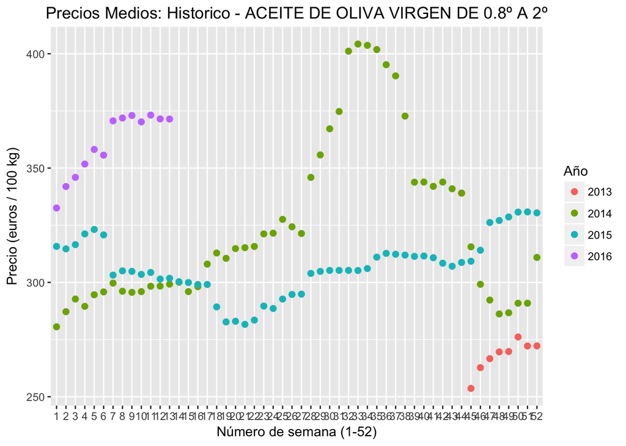

```r
ggplot(a, aes(SEMANA, PRECIO,color = factor(AÑO), name="Año")) + geom_point(size = 2) + ggtitle("Precios Medios: Historico - ACEITE DE OLIVA VIRGEN DE 0.8º A 2º") + theme(plot.title = element_text(hjust = 0.5)) + scale_color_discrete(name = "Año") + xlab("Número de semana (1-52)") + ylab("Precio (euros / 100 kg)")
```

## Precios Medios: Historico - ACEITE DE OLIVA LAMPANTE DE MÁS DE 2º (euros / 100 kg)

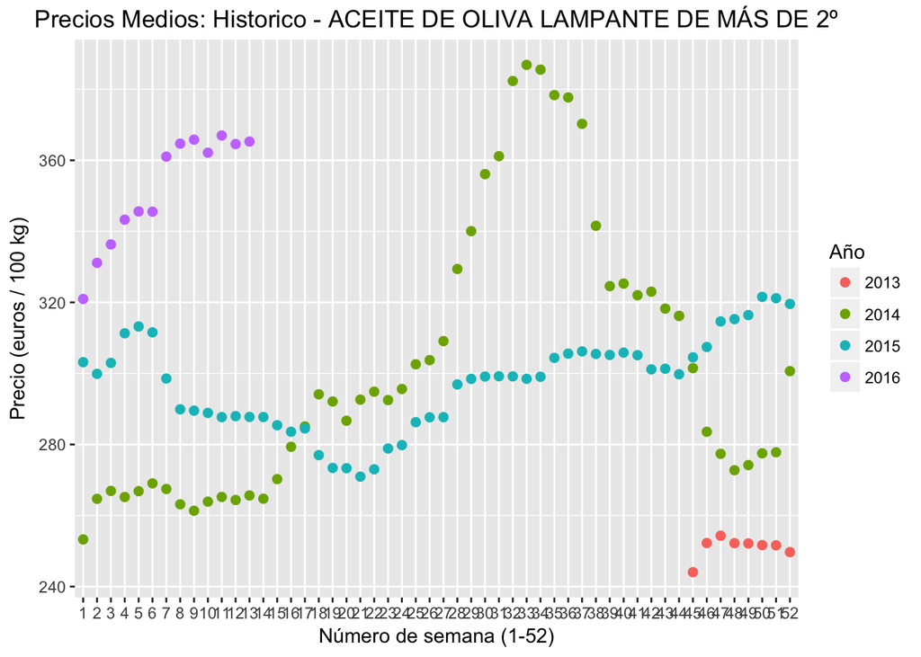

```r
ggplot(a, aes(SEMANA, Pb,color = factor(AÑO), name="Año")) + geom_point(size = 2) + ggtitle("Precios Medios: Historico - ACEITE DE OLIVA LAMPANTE DE MÁS DE 2º") + theme(plot.title = element_text(hjust = 0.5)) + scale_color_discrete(name = "Año") + xlab("Número de semana (1-52)") + ylab("Precio (euros / 100 kg)")
```

## Diferencial de precios Medios: Historico - ACEITE DE OLIVA VIRGEN DE 0.8º A 2º - ACEITE DE OLIVA LAMPANTE DE MÁS DE 2º (euros / 100 kg)

```r
d<-mutate(a,Pc=PRECIO-Pb)
d
```

```
## # A tibble: 126 × 7
##       X1 SEMANA   FECHA    AÑO PRECIO     Pb    Pc
##    <int> <fctr>   <chr> <fctr>  <dbl>  <dbl> <dbl>
## 1      1     44 2013/44   2013 339.05 316.19 22.86
## 2      2     45 2013/45   2013 253.64 244.06  9.58
## 3      3     46 2013/46   2013 262.73 252.26 10.47
## 4      4     47 2013/47   2013 266.66 254.32 12.34
## 5      5     48 2013/48   2013 269.60 252.22 17.38
## 6      6     49 2013/49   2013 269.75 252.14 17.61
## 7      7     50 2013/50   2013 276.14 251.68 24.46
## 8      8     51 2013/51   2013 272.20 251.62 20.58
## 9      9     52 2013/52   2013 272.23 249.70 22.53
## 10    10      1  2014/1   2014 280.58 253.27 27.31
## # ... with 116 more rows
```

## PLOT diferencial de precios Medios: Historico - ACEITE DE OLIVA VIRGEN DE 0.8º A 2º - ACEITE DE OLIVA LAMPANTE DE MÁS DE 2º (euros / 100 kg)

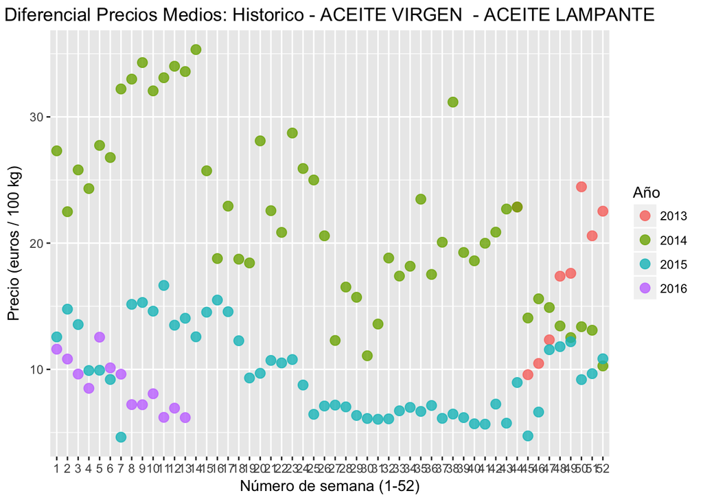

```r
ggplot(d, aes(SEMANA, Pc ,color = factor(AÑO))) + geom_point(size = 3, alpha = .8) + ggtitle("Diferencial Precios Medios: Historico - ACEITE VIRGEN  - ACEITE LAMPANTE") + theme(plot.title = element_text(hjust = 0.5)) + scale_color_discrete(name = "Año") + xlab("Número de semana (1-52)") + ylab("Precio (euros / 100 kg)")
```